# FML - Assignment 5

Nikeeta Rani

2024-04-06

# Loading Necessary Packages

```r
library(stats)
library(cluster)
library(factoextra)
```

# Loading Data

```r
file_path <- read.csv("C:/Users/hp/Desktop/KSU/FML/Assignment 5/Cereals.csv")
cereals<-file_path
```

# Identifying Missing Values

```r
Missing_Data<-colMeans(is.na(cereals))
Missing_Data
```

```
##       name        mfr       type   calories    protein        fat     sodium
## 0.00000000 0.00000000 0.00000000 0.00000000 0.00000000 0.00000000 0.00000000
##      fiber      carbo     sugars     potass   vitamins      shelf     weight
## 0.00000000 0.01298701 0.01298701 0.02597403 0.00000000 0.00000000 0.00000000
##       cups     rating
## 0.00000000 0.00000000
```

# Removing Missing Values

```r
cereals<-na.omit(cereals)
Missing_Data<-colMeans(is.na(cereals))
Missing_Data
```

```
##     name      mfr     type calories  protein      fat   sodium    fiber
##        0        0        0        0        0        0        0        0
##    carbo   sugars   potass vitamins    shelf   weight     cups   rating
##        0        0        0        0        0        0        0        0
```

# Normalizing Numeric Values

```r
num_col <- sapply(cereals, is.numeric)
cereal_num<-cereals[num_col]
cereals_normalized<-scale(cereal_num)
head(cereals_normalized)
```

```
##     calories    protein        fat     sodium       fiber      carbo     sugars
## 1 -1.8659155  1.3817478  0.0000000 -0.3910227  3.22866747 -2.5001396 -0.2542051
## 2  0.6537514  0.4522084  3.9728810 -1.7804186 -0.07249167 -1.7292632  0.2046041
## 3 -1.8659155  1.3817478  0.0000000  1.1795987  2.81602258 -1.9862220 -0.4836096
## 4 -2.8737823  1.3817478 -0.9932203 -0.2702057  4.87924705 -1.7292632 -1.6306324
## 6  0.1498180 -0.4773310  0.9932203  0.2130625 -0.27881412 -1.0868662  0.6634132
## 7  0.1498180 -0.4773310 -0.9932203 -0.4514312 -0.48513656 -0.9583868  1.5810314
##       potass   vitamins      shelf     weight       cups     rating
## 1  2.5605229 -0.1818422  0.9419715 -0.2008324 -2.0856582  1.8549038
## 2  0.5147738 -1.3032024  0.9419715 -0.2008324  0.7567534 -0.5977113
## 3  3.1248675 -0.1818422  0.9419715 -0.2008324 -2.0856582  1.2151965
## 4  3.2659536 -0.1818422  0.9419715 -0.2008324 -1.3644493  3.6578436
## 6 -0.4022862 -0.1818422 -1.4616799 -0.2008324 -0.3038480 -0.9165248
## 7 -0.9666308 -0.1818422 -0.2598542 -0.2008324  0.7567534 -0.6553998
```

# Combined Categorical Values in Normalized Data set

```r
Categorical_Col <- cereals[,1:3]
Cereal_Numerical_Col<-cereals_normalized[,1:13]
cereal_final1 <- cbind(Categorical_Col,Cereal_Numerical_Col)
colnames(cereal_final1)
```

```
##  [1] "name"     "mfr"      "type"     "calories" "protein"  "fat"
##  [7] "sodium"   "fiber"    "carbo"    "sugars"   "potass"   "vitamins"
## [13] "shelf"    "weight"   "cups"     "rating"
```

```r
head(cereal_final1)
```

```
##                        name mfr type   calories    protein        fat
## 1                 100%_Bran   N    C -1.8659155  1.3817478  0.0000000
## 2         100%_Natural_Bran   Q    C  0.6537514  0.4522084  3.9728810
## 3                  All-Bran   K    C -1.8659155  1.3817478  0.0000000
## 4 All-Bran_with_Extra_Fiber   K    C -2.8737823  1.3817478 -0.9932203
## 6   Apple_Cinnamon_Cheerios   G    C  0.1498180 -0.4773310  0.9932203
## 7               Apple_Jacks   K    C  0.1498180 -0.4773310 -0.9932203
##       sodium       fiber      carbo     sugars     potass   vitamins      shelf
## 1 -0.3910227  3.22866747 -2.5001396 -0.2542051  2.5605229 -0.1818422  0.9419715
## 2 -1.7804186 -0.07249167 -1.7292632  0.2046041  0.5147738 -1.3032024  0.9419715
## 3  1.1795987  2.81602258 -1.9862220 -0.4836096  3.1248675 -0.1818422  0.9419715
## 4 -0.2702057  4.87924705 -1.7292632 -1.6306324  3.2659536 -0.1818422  0.9419715
## 6  0.2130625 -0.27881412 -1.0868662  0.6634132 -0.4022862 -0.1818422 -1.4616799
## 7 -0.4514312 -0.48513656 -0.9583868  1.5810314 -0.9666308 -0.1818422 -0.2598542
##       weight       cups     rating
## 1 -0.2008324 -2.0856582  1.8549038
## 2 -0.2008324  0.7567534 -0.5977113
## 3 -0.2008324 -2.0856582  1.2151965
## 4 -0.2008324 -1.3644493  3.6578436
## 6 -0.2008324 -0.3038480 -0.9165248
## 7 -0.2008324  0.7567534 -0.6553998
```

```r
cereal_final1<-as.data.frame(cereal_final1)
cereal_final<-na.omit(cereal_final1)
```

```r
infinite_columns <- sapply(cereal_final, function(x) any(is.infinite(x)))
total_infinite_columns <- sum(infinite_columns)
if (total_infinite_columns > 0) {
  cat("There are", total_infinite_columns, "columns with infinite values in the dataset.\n")
} else {
  cat("No infinite values found in the dataset.\n")
}
```

```
## No infinite values found in the dataset.
```

```r
nan_columns <- sapply(cereal_final, function(x) any(is.nan(x)))
total_nan_columns <- sum(nan_columns)
if (total_nan_columns > 0) {
  cat("There are", total_nan_columns, "columns with NaN values in the dataset.\n")
} else {
  cat("No NaN values found in the dataset.\n")
}
```

```
## No NaN values found in the dataset.
```

# Hierarchical Clustering using Euclidean Distance

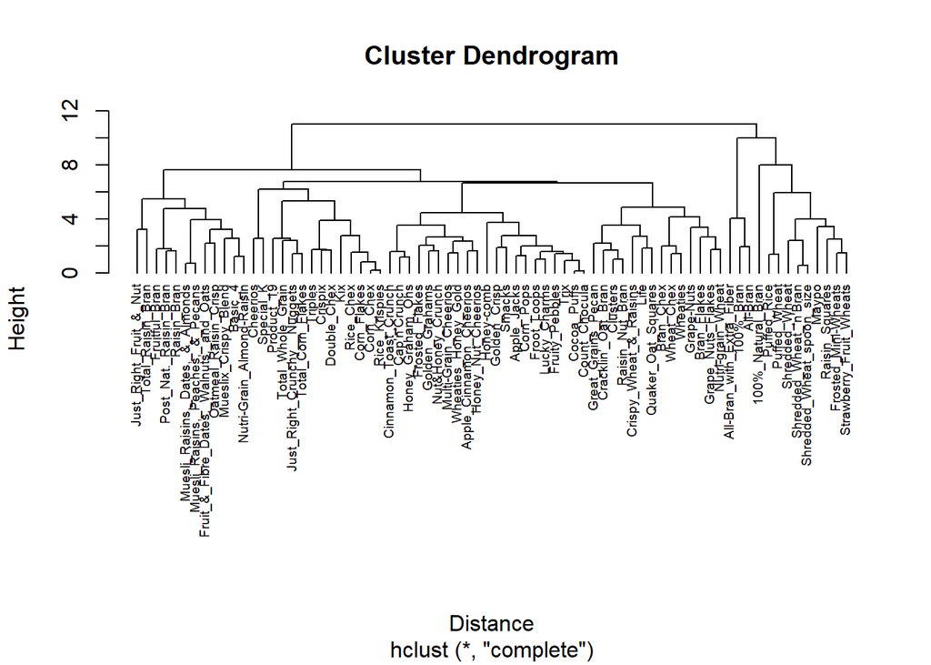

```r
rownames(cereals_normalized) <- Categorical_Col[, 1]
Distance <- dist(cereals_normalized, method = "euclidean")
hc1<-hclust(Distance, method = "complete") # using complete linkage
plot(hc1, cex= 0.6, hang = -1)
```

# Computing with Agnes and with different linkage method

```r
hc_single<-agnes(cereals_normalized, method = "single")
hc_complete<-agnes(cereals_normalized, method = "complete")
hc_average<-agnes(cereals_normalized, method = "average")
hc_ward<-agnes(cereals_normalized, method = "ward")
```

```r
print(hc_single$ac)
```

```
## [1] 0.6067859
```

```r
print(hc_complete$ac)
```

```
## [1] 0.8353712
```

```r
print(hc_average$ac)
```

```
## [1] 0.7766075
```

```r
print(hc_ward$ac)
```

```
## [1] 0.9046042
```

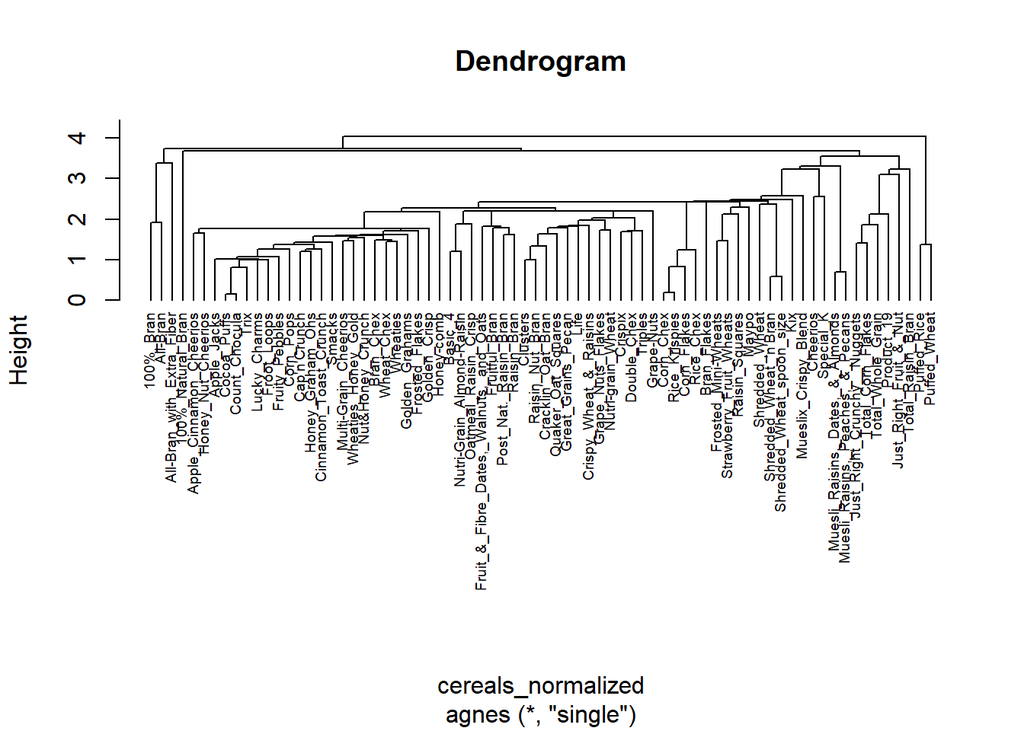

```r
pltree(hc_single, cex=0.6, hang=-1, main = "Dendrogram")
```

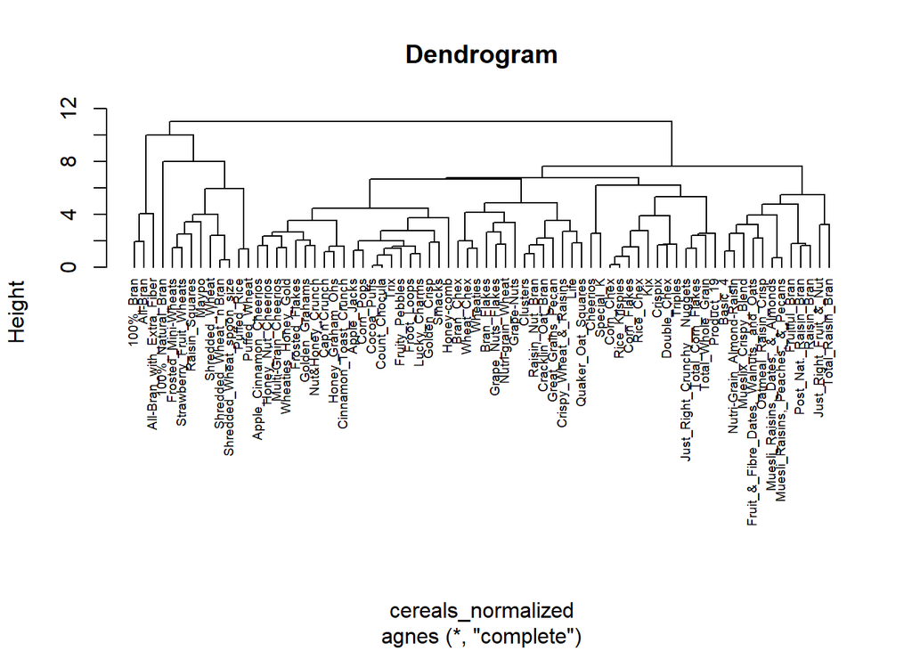

```r
pltree(hc_complete, cex=0.6, hang=-1, main = "Dendrogram")
```

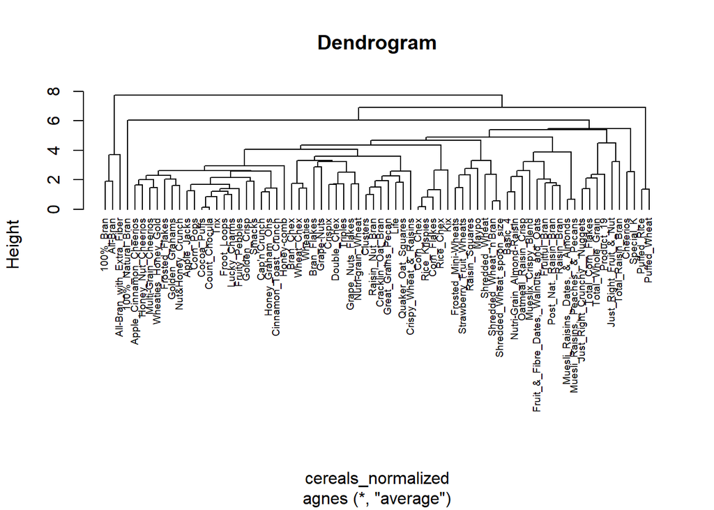

```r
pltree(hc_average, cex=0.6, hang=-1, main = "Dendrogram")
```

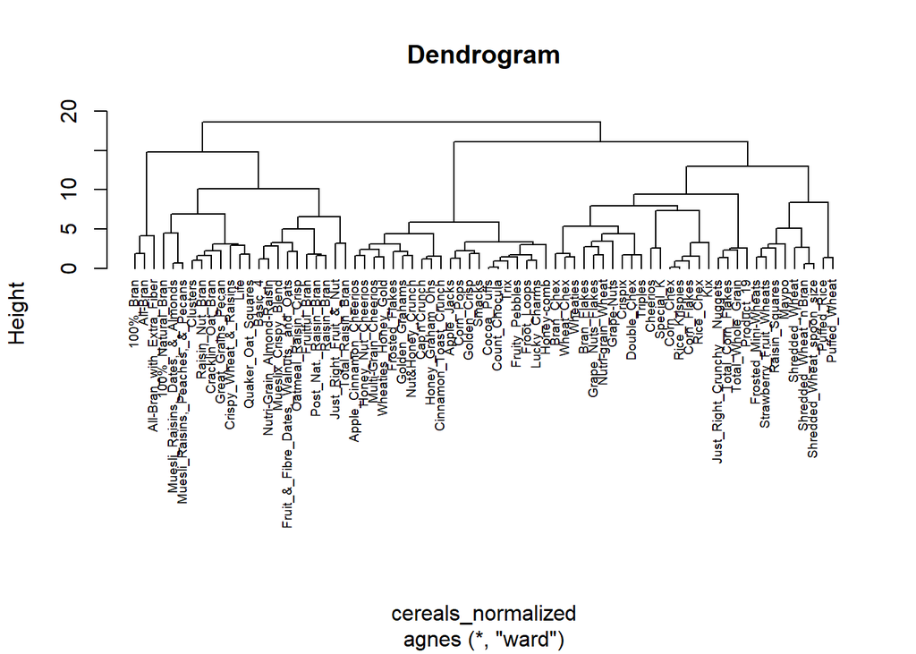

```r
pltree(hc_ward, cex=0.6, hang=-1, main = "Dendrogram")
```

### Analysis: Ward linkage is the best method for this data. It has has the highest agglomerative Coefficient i.e 0.9046042 (nearest to 1) which shows that it has the highest cohesion in clusters as compared to other methods used above. It gives more balanced cluster while minimizing the variance within each clusters.

# Identifying Number of Clusters using Elbow method

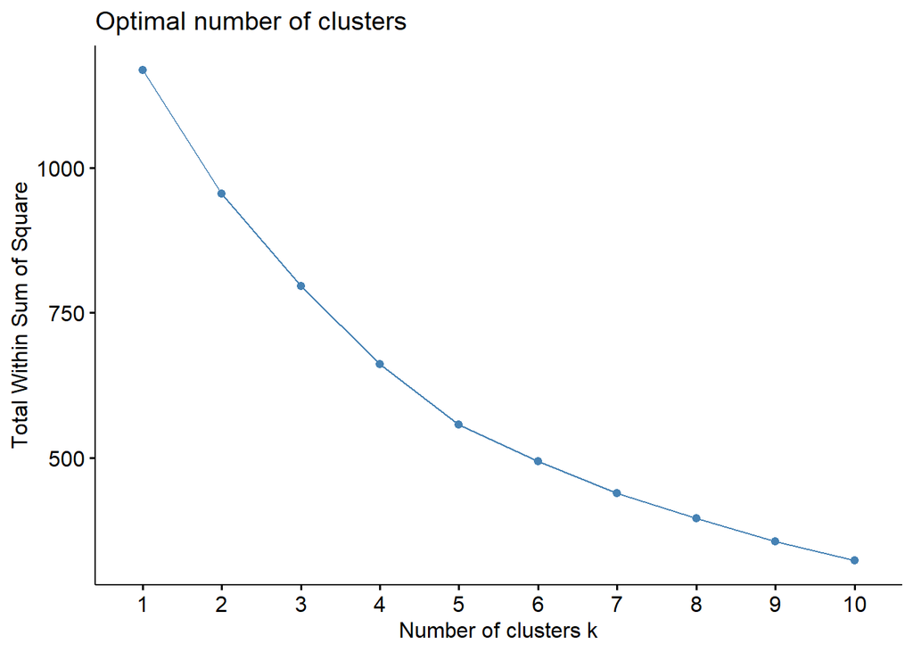

```r
set.seed(123)
fviz_nbclust(cereal_final, FUN = hcut, method = "wss")
```

```r
no_of_Clusters <- cutree(hc_ward, k = 5)
```

```r
num_clusters <- length(unique(no_of_Clusters))
print(num_clusters)
```

```
## [1] 5
```

### Analysis: Total numbers of clusters formed by using Ward Linkage method is 5.

# Identifying Structure and stability of the Clusters:

```r
Combined_data<-as.data.frame(cbind(cereal_final, no_of_Clusters))
numeric_data <- Combined_data[, sapply(Combined_data, is.numeric)]
```

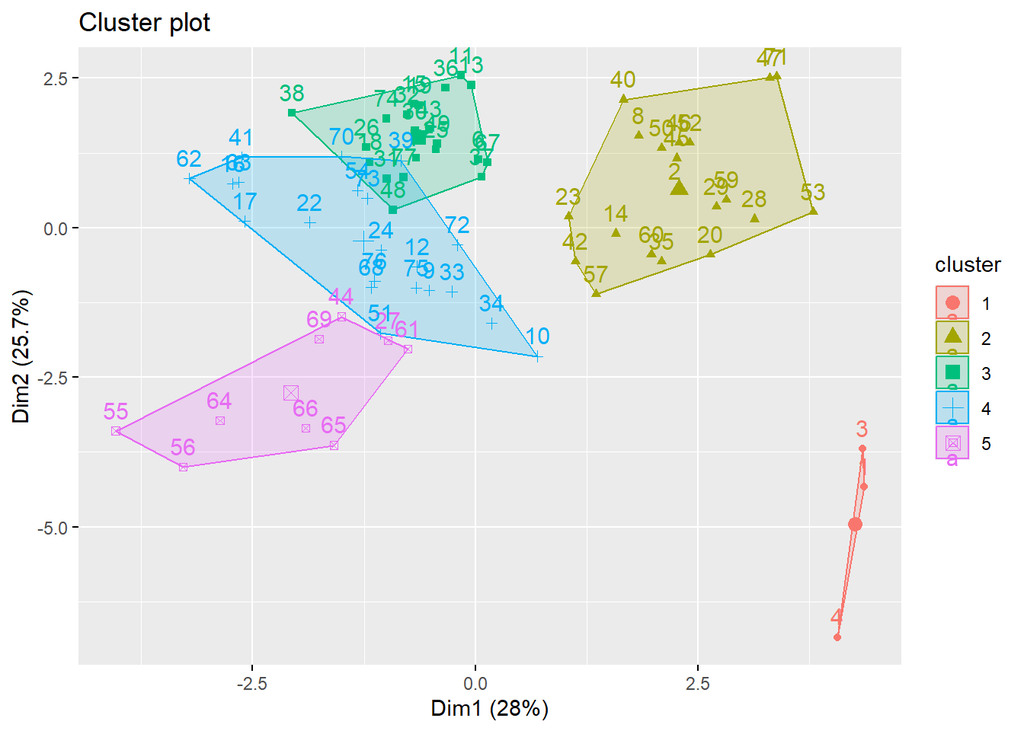

```r
fviz_cluster(list(data = numeric_data, cluster = no_of_Clusters))
```

```r
centroids <- t(sapply(unique(no_of_Clusters), function(cluster) {
  colMeans(numeric_data[no_of_Clusters == cluster, ])
}))
print(centroids)
```

```
##        calories     protein        fat      sodium       fiber      carbo
## [1,] -2.2018711  1.38174776 -0.3310734  0.17279012  3.64131237 -2.0718749
## [2,]  0.8553248  0.59163927  0.9435592 -0.08898011  0.38141771 -0.2003584
## [3,]  0.1978117 -0.91996886  0.0000000  0.12101140 -0.66198437 -0.5423583
## [4,] -0.1621407  0.18662567 -0.4729620  0.77112209 -0.21003997  0.9626860
## [5,] -1.2499969 -0.06420242 -0.8828625 -1.94150793 -0.02664224  0.1551013
##          sugars     potass    vitamins      shelf     weight       cups
## [1,] -0.7894824  2.9837813 -0.18184220  0.9419715 -0.2008324 -1.8452553
## [2,]  0.5143002  0.7475659  0.09849786  0.8217889  0.9235649 -0.5477863
## [3,]  0.9583619 -0.7415648 -0.18184220 -0.6604628 -0.2008324  0.2779676
## [4,] -0.8659505 -0.3485391  0.45893508 -0.1453946 -0.2008324  0.4577648
## [5,] -1.0953551 -0.1122758 -0.80482011 -0.2598542 -1.0482044  0.1156788
##          rating no_of_Clusters
## [1,]  2.2426479              1
## [2,] -0.2928786              2
## [3,] -0.9636465              3
## [4,]  0.2916795              4
## [5,]  1.4712151              5
```

## Creating Partitions

```r
set.seed(123)  # For reproducibility
indices <- sample(nrow(cereals_normalized), size = 0.5 * nrow(cereals_normalized))
Partition_A <- cereals_normalized[indices, ]
Partition_B <- cereals_normalized[-indices, ]

agnes_single<-agnes(Partition_A, method = "single")
agnes_average<-agnes(Partition_A, method = "average")
agnes_complete<-agnes(Partition_A, method = "complete")
agnes_ward<-agnes(Partition_A, method = "ward")
```

```r
agnes_single$ac
```

```
## [1] 0.5677606
```

```r
agnes_average$ac
```

```
## [1] 0.68553
```

```r
agnes_complete$ac
```

```
## [1] 0.7696915
```

```r
agnes_ward$ac
```

```
## [1] 0.8467852
```

```r
hc_A <- agnes(Partition_A, method = "ward")
cut_A <- cutree(hc_A, k = 5)
centroids_A <- aggregate(Partition_A, by=list(cut_A), FUN=mean)
```

```r
assign_Centeroid <- function(observation, centroids) {
  distances <- apply(centroids[, -1], 1, function(centroid) sum((observation - centroid)^2))
  return(which.min(distances))
}
cluster_assignments_B <- apply(Partition_B, 1, assign_Centeroid, centroids_A)
```

```r
hc_full <- agnes(cereals_normalized, method = "ward")
cut_full <- cutree(hc_full, k = 5)
table(cluster_assignments_B, cut_full[-indices])
```

```
##
## cluster_assignments_B  1  2  3  4  5
##                     1  2  1  0  4  5
##                     2  1  2  0  0  0
##                     3  0  1 10  0  0
##                     4  0  0  0  7  0
##                     5  0  4  0  0  0
```

# Identifying Optimal Cluster for Healthy Cereal

```r
cereals_clean <- cereals[complete.cases(cereals), ]
agnes_ward <- agnes(cereals_clean[, -c(1:3)], method="ward")


hc_ward <- as.hclust(agnes_ward)
clustering <- cutree(hc_ward, k=5)


if(length(clustering) == nrow(cereals_clean)) {
  # Calculate the cluster means
  cluster_means <- aggregate(cereals_clean[, -c(1:3)], by = list(cluster = clustering), FUN = mean)

  # Identify the 'healthy' cluster
  healthy_cluster_index <- which.max(cluster_means$fiber + cluster_means$protein  - cluster_means$sugar - cluster_means$fat)
  healthy_cluster <- cluster_means[healthy_cluster_index, ]
} else {
  stop("The number of cluster assignments does not match the number of rows in the dataset.")
}
```

```r
print(cluster_means)
```

```
##   cluster calories  protein       fat   sodium     fiber    carbo    sugars
## 1       1 112.1429 3.357143 1.4285714 172.5000 5.6071429 12.03571  9.142857
## 2       2  86.0000 2.500000 0.6000000   3.0000 2.1000000 14.60000  2.900000
## 3       3 110.3226 2.290323 1.1612903 187.5806 1.5645161 14.91935  7.645161
## 4       4 110.0000 1.750000 0.8750000 100.6250 0.8750000 11.75000 12.125000
## 5       5 108.1818 2.636364 0.4545455 268.1818 0.5454545 19.90909  3.181818
##      potass vitamins    shelf   weight      cups   rating
## 1 217.14286 30.35714 2.928571 1.160000 0.6614286 46.01532
## 2  95.00000 10.00000 2.100000 0.883000 0.8640000 60.11492
## 3  80.16129 34.67742 2.161290 1.039032 0.8003226 37.30956
## 4  38.75000 25.00000 2.000000 1.000000 0.8387500 33.65472
## 5  45.90909 31.81818 1.727273 1.000000 1.0345455 42.21039
```

```r
print(healthy_cluster_index)
```

```
## [1] 2
```

```r
print(healthy_cluster)
```

```
##   cluster calories protein fat sodium fiber carbo sugars potass vitamins shelf
## 2       2       86     2.5 0.6      3   2.1  14.6    2.9     95       10   2.1
##   weight  cups   rating
## 2  0.883 0.864 60.11492
```

## Analysis: Cluster 2 represents the best cluster for “healthy cereals” because it has less sugar content and fat and contains good amount od fiber and protein as compared to other clusters.

### Why Normalization is Important

It is necessary to normalize to data for the clustering as it is sensitive to outliers and noise. Each feature has different scales and units, to scale them in one unit, we normalize the data because in clustering, clusters are formed based on the distances between each data point. After normalizing every feature carries the equal weight when they are assigned to clusters. without normalization, if there any outlier exists in the data, it will have huge impact on the clusters formations.